# 1. Introduction

- course logistics
- overall motivation
- decomposing interpretability

## Course Logistics

### Office Hours

*Instructor*

- Kris Sankaran [ksankaran@wisc.edu]

*TAs*

- Jiaxin Ye [jye73@wisc.edu]

We will announce in-person and virtual office hours depending on the results of the poll on the syllabus. Submit your preferences by **Sunday at 6pm**.

### Weekly rhythm

- Tuesday: New methods
- Thursday: Case study
  - Both days: Short discussions/exercises
- Friday (every ~ 2 weeks)
  - HW1 February 6
  - HW2 Feburuary 20

### Learning outcomes

- **Compare** the competing definitions of interpretable machine learning, the motivations behind them, and metrics that can be used to quantify whether they have been met.
- Within a specific application context, **evaluate** the trade-offs associated with competing interpretable machine learning techniques.
- **Describe** the theoretical foundation of intrinsically interpretable models like sparse regression, gaussian processes, and classification and regression trees, and **apply** them to realistic case studies with appropriate validation checks.

### Learning outcomes

- **Describe** the theoretical foundation of post-hoc explanation methods like SHAP and linear probes values and **apply** them to realistic case studies with appropriate validation checks
- **Analyze** large-scale foundation models using methods like sparse autoencoders and **describe** their relevance to problems of model control and AI-driven design.

## Class Resources

- Slides and Readings
- Assignments. Discussion, In-Class Exercises, HW.
- [Piazza](https://piazza.com/wisc/spring2026/sp26stat479003/home): https://piazza.com/wisc/spring2026/sp26stat479003/home
- [Canvas Page](https://canvas.wisc.edu/courses/499874/modules): https://canvas.wisc.edu/courses/499874/modules
  - links to everything else

### Late Policy

Late submissions are penalized 10% per day late, up to 5 days. No submissions accepted after that.

- Two 24 hour grace periods for HW
- Four 24 hour grace periods for in-class discussion and exercises

### Evaluation

- In-Class Discussion and Exercises: 20%
- Midterm (week 8) + Final Exam: 35%
- Homeworks: 45%

### Expectations

- In-class submissions are graded for completeness. These are designed to help you gauge your understanding and help the instructors with pacing.
- Homeworks will be graded for correctness according to the provided rubric.
- Exams will refer to concepts from the reading. If you master the readings, you will do well.

### Teaching Philosophy

- I have curated materials to guide you through the subject. But only you can do the work to master the topic. Read, reflect, ask questions.
- To learn deeply, it helps to study the same object from many angles. I hope to share learning techniques that you can use beyond this class.
- I think this topic is important in the real world. We need knowledgeable and wise data scientists who can build interpretable ML systems.

## What is interpretability?

## Reading

- Lipton, Z. C. (2018). The Mythos of Model Interpretability. ACM Queue: Tomorrow’s Computing Today, 16(3), 31–57. https://doi.org/10.1145/3236386.3241340
- Murdoch, W. J., Singh, C., Kumbier, K., Abbasi-Asl, R., & Yu, B. (2019). Definitions, methods, and applications in interpretable machine learning. Proceedings of the National Academy of Sciences of the United States of America, 116(44), 22071–22080. https://doi.org/10.1073/pnas.1900654116

### What can go wrong?

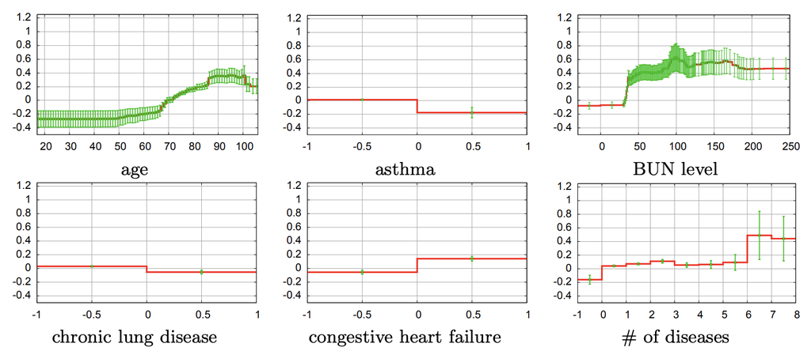

Example from (Caruana et al. 2015).

### What can go wrong?

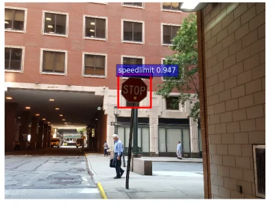

Example from (Gu et al. 2019).

### What can go wrong?

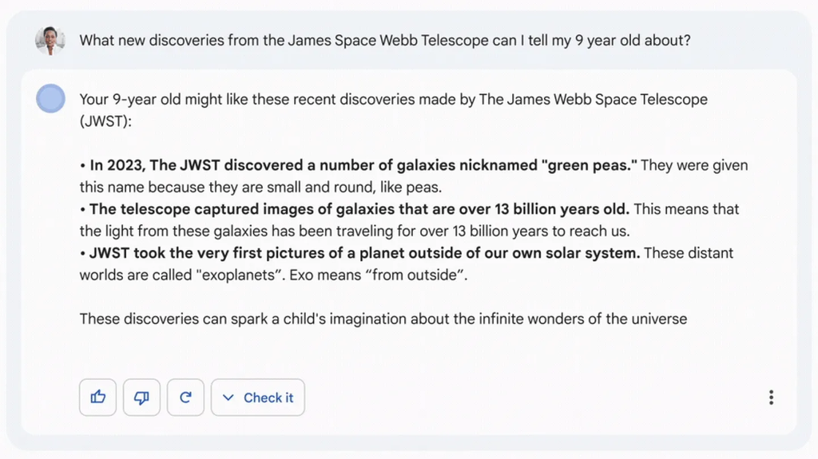

### What can go wrong?

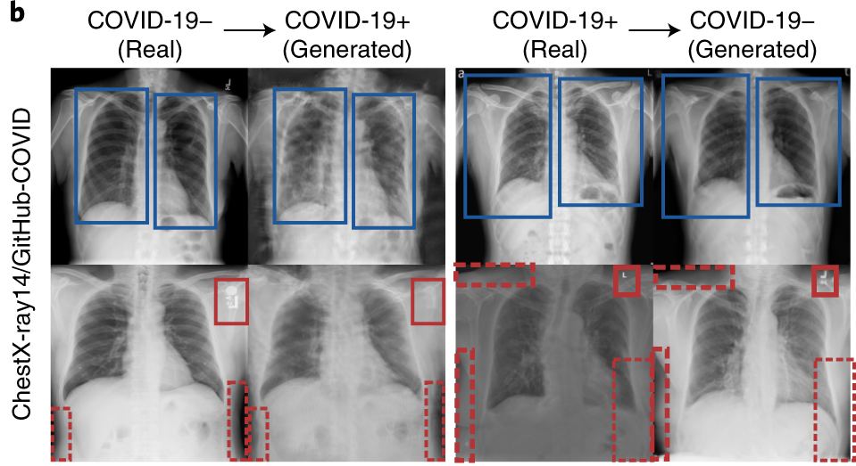

Example from (DeGrave et al. 2021).

### Problems

- Fairness
- Safety
- Misinformation

### Formulation gaps

- In machine learning, most effort is directed towards ensuring models have good performance metrics on external benchmark data sets.
- Models learning this way can be very accurate according to easily measured criteria like accuracy or computational efficiency but inappropriate with respect to properties that are harder to measure.
- The gap between what we want our models to achieve and what we can easily encode in performance metrics is called a formulation gap.

### Formulation gaps: Trust

- Would you be willing to relinquish control to the model?
- The answer depends on how it manages individual cases, not just than overall accuracy.

[figure not shown]

### Formulation gaps: Transferability

- Typical benchmarks randomly split data into training vs. test sets.
- Models are often used in settings that don’t match those original training/test splits.
- The use of models might themselves change the distribution of the data (pneumonia example from before).

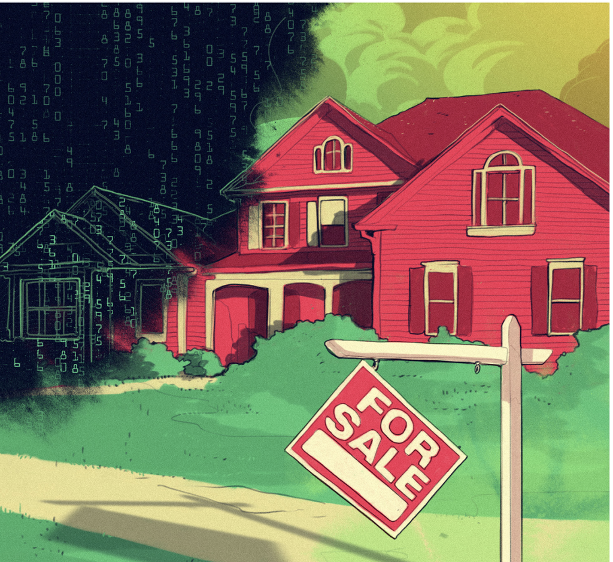

See (Vern L. Glaser and Safavi 2023).

### Formulation gaps: Informativeness

- Models are often used to support discovery. This is a different task than automation.
- While this is often an argument for using “white box” models, black boxes can still support discovery, e.g., by identifying similar cases in a medical diagnosis system.

### Formulation gaps: Ethics

- Models might amplify existing biases if only test accuracy is considered.
- Fairness metrics have been defined to help guard against this risk, but there is no universal metric for fairness. Interpretability can help address broader demands for transparency.

[figure not shown]

### Discussion: Past Experience

Introduce yourself to your neighbors. What is your name and degree program? What are your areas of interest? How might interpretability or explainability be helpful in the work that you do?

Then respond to [Past Experience] in the exercise sheet.

### PDR Framework

- Reference (Murdoch et al. 2019) also breaks the vague concept of “interpretability” down into precise elements which can be more formally evaluated.
- Together, this helps establish trust in the reliability of the results, which is important in interdisciplinary work.

## It also helps protect against unintended consequences that can arise after model deployment.

### PDR Framework: Accuracy

- **Predictive Accuracy**: The model-to-explain has to be accurate. There is not point “interpreting” a model that gives a poor approximation of reality.
- **Descriptive Accuracy**: The interpretation should be faithful to the model. This is the extent to which the explanation reflects what the black box actually learned, which is not necessarily the same as what it was designed to learn.

### The PDR Desiderata: Relevancy

- Interpretations don’t exist in a vacuum. Like data visualizations, their complexity needs to be suitable to their audience.
- For example, we might give three different explanations of the same model depending on whether we are communicating with biologists, clinicians, or statisticians.
- Whether the interpretability outputs are relevant to their audience can be gauged by their adoption in specific scientific settings or how they are actually used by participants in user studies.

### Spectrum of evaluation

Reference (Doshi-Velez and Kim 2017) notes that new interpretability techniques can be evaluated at several levels.

- Functionally-grounded: Define computational proxy tasks that can be measured without studying real users.
- Human-grounded: Consider simplified tasks that can be solved by general audience members. This can involve crowdsourcing.
- Application grounded: Evaluate in the field with representative experts in a concrete end-use case.

### Phases of method development

- These different types of evaluation can inform one another. For example, we can define new proxy tasks based on the most challenging steps for experts.
- New methods that do well in computational proxies are worth investigating through user studies.

### Benchmarking

- Each of these types fo evaluation will come with their own performance metrics.
- We will revisit this question periodically as we introduce new methods and study the contexts in which they are worth applying.

Caruana, Rich, Yin Lou, Johannes Gehrke, Paul Koch, M. Sturm, and Noémie Elhadad. 2015. “Intelligible Models for HealthCare: Predicting Pneumonia Risk and Hospital 30-Day Readmission.” *Proceedings of the 21th ACM SIGKDD International Conference on Knowledge Discovery and Data Mining*.

DeGrave, Alex J., Joseph D. Janizek, and Su-In Lee. 2021. “AI for Radiographic COVID-19 Detection Selects Shortcuts over Signal.” *Nature Machine Intelligence* 3 (7): 610–19. https://doi.org/10.1038/s42256-021-00338-7.

Doshi-Velez, Finale, and Been Kim. 2017. *Towards a Rigorous Science of Interpretable Machine Learning*. arXiv. https://doi.org/10.48550/ARXIV.1702.08608.

Gu, Tianyu, Kang Liu, Brendan Dolan-Gavitt, and Siddharth Garg. 2019. “BadNets: Evaluating Backdooring Attacks on Deep Neural Networks.” *IEEE Access* 7: 47230–44. https://doi.org/10.1109/access.2019.2909068.

Murdoch, W. James, Chandan Singh, Karl Kumbier, Reza Abbasi-Asl, and Bin Yu. 2019. “Definitions, Methods, and Applications in Interpretable Machine Learning.” *Proceedings of the National Academy of Sciences* 116 (44): 22071–80. https://doi.org/10.1073/pnas.1900654116.

Vern L. Glaser, Omid Omidvar, and Mehdi Safavi. 2023. *Predictive Models Can Lose the Plot. Here’s How to Keep Them on Track. — Sloanreview.mit.edu*. [Https://sloanreview.mit.edu/article/predictive-models-can-lose-the-plot-heres-how-to-keep-them-on-track/](https://sloanreview.mit.edu/article/predictive-models-can-lose-the-plot-heres-how-to-keep-them-on-track/).